# PML- Prediction Assignment Writeup

```r
library("readr")
library("data.table")
library("caret")
library("doParallel")
library("rpart.plot")
library("reshape2")
library("ggplot2")
```

This project consists on predicting how well people use exercize devices like “Fitbit” or so. We will use a large file of measurement data from accelerometers on the belt, forearm, arm, and dumbell of 6 participants.They were asked to perform barbell lifts correctly and incorrectly in 5 different ways. In the file, class A corresponds to the specified execution of the exercise, while the other 4 classes correspond to common mistakes

Looking briefly at the file structure, there are lines with raw data for the measures and lines which include some statistical measures for each window as indicated in the paper of the study. For the measurement lines, the statistical values are NA.  
If we look at the structure of the test file, we do not have statistics lines for the windows, but only the raw data lines.  
To be usable, the model we will build should therefore only use raw data for forecasting. Consequently, we choose to keep only the raw data variables in the training file and we eliminate the statistics columns. We also remove the first 7 columns which are names / times specific to the generation of the file, and will not be used for a model.

## Loading the data

```r
pml_data <- fread("pml-training.csv",header = TRUE)
dropcols  <- names(pml_data)[grepl( "kurtosis" , names(pml_data)) | grepl( "skewness" , names(pml_data)) | grepl( "max" , names(pml_data)) | grepl( "min" , names(pml_data)) | grepl( "var" , names(pml_data)) | grepl( "amplitude" , names(pml_data)) | grepl( "avg" , names(pml_data)) | grepl( "std" , names(pml_data))]
set(pml_data, ,dropcols, NULL) # Dropping the statisics columns

pml_data[,"classe"] <- factor(pml_data$classe)
pml_data  <- pml_data[,-c(1,2,3,4,5,6,7)] # Dropping the first 7 columns

addTaskCallback(function(...) {set.seed(1138);TRUE})  # Set seed for reproductibility, for each function calls
inTraining <- createDataPartition(pml_data$classe, p = .8, list=FALSE) # Splitting the file in 2: 80% for training, 20% for testing.
training <- pml_data[inTraining, ]
testing <- pml_data[-inTraining, ]

x <- training[,-53]  # Split to x,y for futher use, because in Caret, formula is slower
y <- training$classe
```

```r
pml_data[!complete.cases(pml_data),] # Controling that there are no remainin "NA"s
```

```
## Empty data.table (0 rows and 53 cols): roll_belt,pitch_belt,yaw_belt,total_accel_belt,gyros_belt_x,gyros_belt_y...
```

53 variables are obtained for a total of 19622 observations.

**Loading of the final test file**

```r
pml_test <- fread("pml-testing.csv",header = TRUE)
set(pml_test, ,dropcols, NULL)

pml_test  <- pml_test[,-c(1,2,3,4,5,6,7)]
```

**An eye on variables**

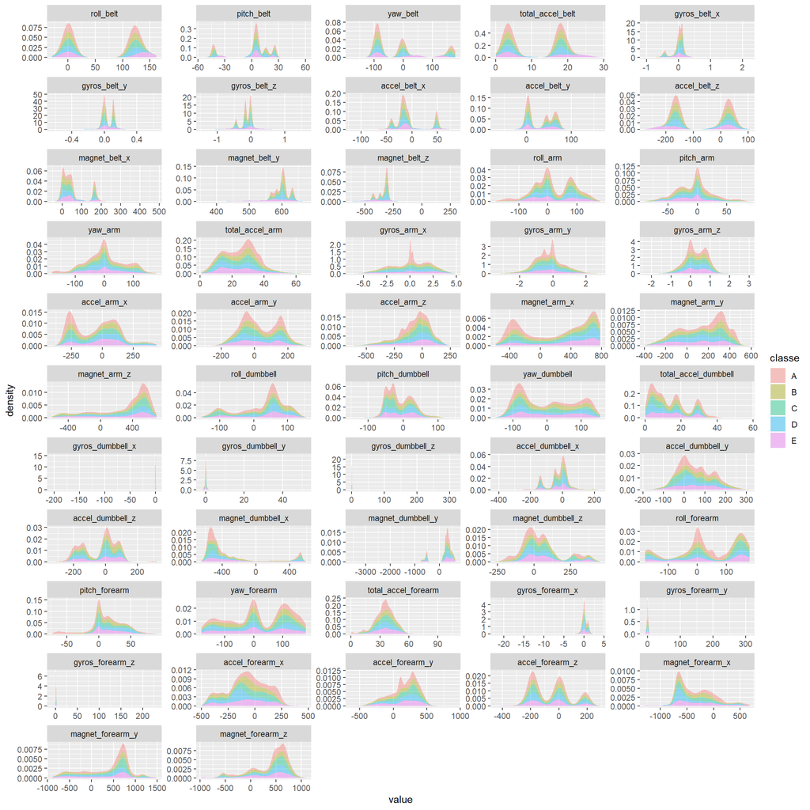

```r
melt.pml_data <- melt(pml_data)
ggplot(data = melt.pml_data, aes(x = value,fill = classe)) +
        stat_density(alpha=.4) +
        facet_wrap(~variable, scales = "free",ncol=5)
```

Some variables seems skewed and not scaled well comparing to others (gyros). It should not be a problem because we are going to use classification tree modelling.

## CART modelling

We will fist try a CART modelling (single classification tree) using rpart. We use classical parameters : Pruning of the tree is controlled by the complexity parameter (cp), which imposes a penalty to the tree for having two many splits. The default value is 0.01. The higher the cp, the smaller the tree. We use cross-validation approaches to determine the corresponding prediction accuracy of the model. Here a classical value of 10-fold cross validation is repeated 3 times. The tuneLength parameter is used to determine the total number of combinations that will be evaluated for the CP parameter.

The plotting of the resulting tree will give us an idea of the rules taken by the model.

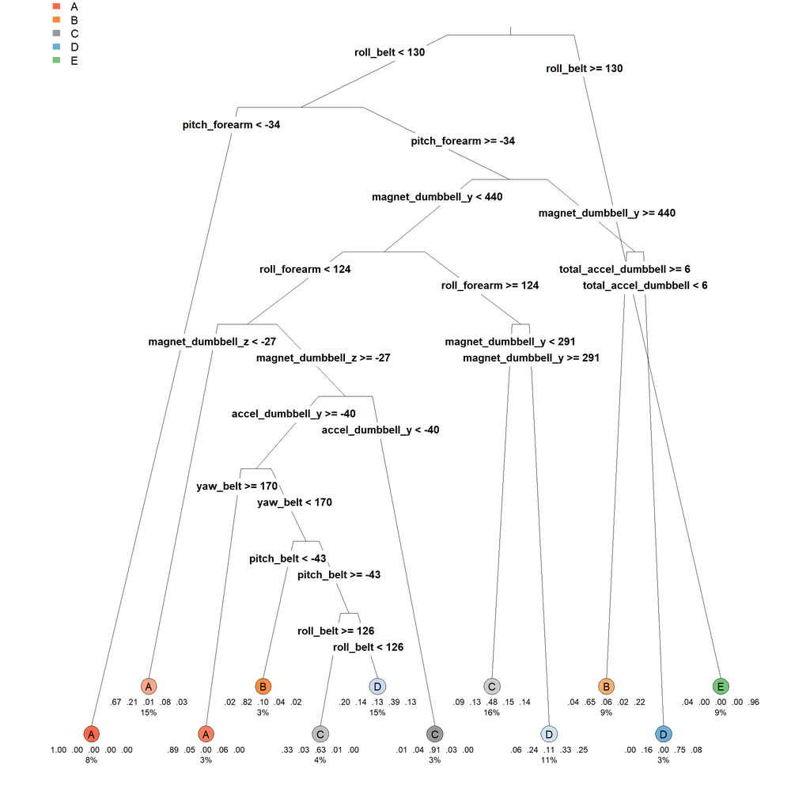

```r
trctrl <- trainControl(method = "repeatedcv", number = 10, repeats = 3)
model<- train(classe ~., training, method = "rpart",
                    parms = list(split = "gini"),
                    trControl=trctrl,
                    tuneLength = 6)

rpart.plot(model$finalModel, type = 3, clip.right.labs = FALSE, branch = .3, under = TRUE)
```

```r
model
```

```
## CART
##
## 15699 samples
##    52 predictor
##     5 classes: 'A', 'B', 'C', 'D', 'E'
##
## No pre-processing
## Resampling: Cross-Validated (10 fold, repeated 3 times)
## Summary of sample sizes: 14129, 14130, 14129, 14129, 14130, 14128, ...
## Resampling results across tuning parameters:
##
##   cp          Accuracy   Kappa
##   0.02047174  0.6368125  0.54277244
##   0.02078327  0.6185904  0.51709808
##   0.02857143  0.5270620  0.38351490
##   0.03408990  0.5019658  0.34979031
##   0.05999110  0.4355858  0.24219360
##   0.11517579  0.3159416  0.04846076
##
## Accuracy was used to select the optimal model using the largest value.
## The final value used for the model was cp = 0.02047174.
```

```r
varImp(model)
```

```
## rpart variable importance
##
##   only 20 most important variables shown (out of 52)
##
##                      Overall
## roll_belt            100.000
## yaw_belt              86.423
## pitch_forearm         85.273
## roll_forearm          75.986
## magnet_dumbbell_z     69.178
## accel_dumbbell_y      58.470
## magnet_dumbbell_y     52.353
## pitch_belt            49.392
## yaw_arm               38.085
## accel_belt_z          35.961
## magnet_belt_y         34.653
## total_accel_belt      29.794
## roll_dumbbell         26.981
## accel_forearm_x       24.703
## magnet_arm_x          22.048
## accel_arm_x           21.192
## total_accel_dumbbell  15.936
## roll_arm              12.944
## magnet_belt_z         10.837
## magnet_arm_y           8.767
```

```r
pred <-predict(model,newdata=testing)
print(confusionMatrix(data=pred,reference=testing$classe))
```

```
## Confusion Matrix and Statistics
##
##           Reference
## Prediction   A   B   C   D   E
##          A 825 142   9  54  21
##          B  17 287  26   8  88
##          C 108  96 525  80  75
##          D 148 234 124 501 188
##          E  18   0   0   0 349
##
## Overall Statistics
##
##                Accuracy : 0.634
##                  95% CI : (0.6187, 0.6491)
##     No Information Rate : 0.2845
##     P-Value [Acc > NIR] : < 2.2e-16
##
##                   Kappa : 0.5404
##
##  Mcnemar's Test P-Value : < 2.2e-16
##
## Statistics by Class:
##
##                      Class: A Class: B Class: C Class: D Class: E
## Sensitivity            0.7392  0.37813   0.7675   0.7792  0.48405
## Specificity            0.9195  0.95607   0.8892   0.7884  0.99438
## Pos Pred Value         0.7850  0.67371   0.5939   0.4192  0.95095
## Neg Pred Value         0.8987  0.86503   0.9477   0.9479  0.89539
## Prevalence             0.2845  0.19347   0.1744   0.1639  0.18379
## Detection Rate         0.2103  0.07316   0.1338   0.1277  0.08896
## Detection Prevalence   0.2679  0.10859   0.2253   0.3046  0.09355
## Balanced Accuracy      0.8294  0.66710   0.8284   0.7838  0.73921
```

Acurracy is quite low even with optimum cp value. We will not go further on tuning this model. The random forests are generally more efficient.

## Random Forests modelling

As it is written in LG’s web site “Improving Performance of Random Forest in caret::train()”, train function in its default uses bootstrap sampling (25 times): the bootstrapping resampling method causes a significant increase in processing time. Comparing to the cross-validation resampling method, the bootstrapping resampling method had no positive impact on model accuracy. We will then use a 5-fold cross-validation parameter.

**First model (default)**

```r
# Define a function to give the OOB as it is not a model property in Caret.
OOBErr <- function (x)
{
  cm <- x$confusion
  cm <- cm[, -ncol(cm)]
  (1 - sum(diag(cm)) / sum(cm)) * 100
}


t1=proc.time() # Record time for measurement


fitControl <- trainControl(method = "cv",
                           number = 5,
                           allowParallel = TRUE)

cls = makeCluster(detectCores() - 1)  # initialise parallel computations

registerDoParallel(cls)
getDoParWorkers()
```

```
## [1] 7
```

```r
fit <- train(x,y, method="rf",trControl = fitControl)
stopCluster(cls)
registerDoSEQ()

t2=proc.time()
(t2-t1)/60
```

```
##      user    system   elapsed
## 0.6718333 0.0050000 4.2300000
```

```r
fit
```

```
## Random Forest
##
## 15699 samples
##    52 predictor
##     5 classes: 'A', 'B', 'C', 'D', 'E'
##
## No pre-processing
## Resampling: Cross-Validated (5 fold)
## Summary of sample sizes: 12558, 12559, 12561, 12559, 12559
## Resampling results across tuning parameters:
##
##   mtry  Accuracy   Kappa
##    2    0.9933752  0.9916194
##   27    0.9921014  0.9900081
##   52    0.9859224  0.9821900
##
## Accuracy was used to select the optimal model using the largest value.
## The final value used for the model was mtry = 2.
```

```r
OOBErr(fit$finalModel)
```

```
## [1] 0.5605453
```

```r
pred <-predict(fit,newdata=testing)
confusionMatrix(data=pred,reference=testing$classe)
```

```
## Confusion Matrix and Statistics
##
##           Reference
## Prediction    A    B    C    D    E
##          A 1116    9    0    0    0
##          B    0  750    3    0    0
##          C    0    0  680   13    0
##          D    0    0    1  629    0
##          E    0    0    0    1  721
##
## Overall Statistics
##
##                Accuracy : 0.9931
##                  95% CI : (0.99, 0.9955)
##     No Information Rate : 0.2845
##     P-Value [Acc > NIR] : < 2.2e-16
##
##                   Kappa : 0.9913
##
##  Mcnemar's Test P-Value : NA
##
## Statistics by Class:
##
##                      Class: A Class: B Class: C Class: D Class: E
## Sensitivity            1.0000   0.9881   0.9942   0.9782   1.0000
## Specificity            0.9968   0.9991   0.9960   0.9997   0.9997
## Pos Pred Value         0.9920   0.9960   0.9812   0.9984   0.9986
## Neg Pred Value         1.0000   0.9972   0.9988   0.9957   1.0000
## Prevalence             0.2845   0.1935   0.1744   0.1639   0.1838
## Detection Rate         0.2845   0.1912   0.1733   0.1603   0.1838
## Detection Prevalence   0.2868   0.1919   0.1767   0.1606   0.1840
## Balanced Accuracy      0.9984   0.9936   0.9951   0.9890   0.9998
```

OOB error is quite low, related to high accuracy.

“mtry”" is the number of variables available for splitting at each tree node. For RF classification models, the default is the square root of the number of predictor variables (rounded down), so 7 in our case. The default three random selection of mtry seems quite not beeing optimal: we are going to make some tuning to have even a better accuracy for the model.

**Second model (tuning for mtry)**

```r
t1=proc.time() # Record time for measurement

tunegrid <- expand.grid(.mtry=c(4:18)) # try several values for mtry

cls = makeCluster(detectCores() - 1)  # initialise parallel computations
registerDoParallel(cls)
fit <- train(x,y, method="rf",trControl = fitControl,tuneGrid=tunegrid)
stopCluster(cls)
registerDoSEQ()

t2=proc.time()
(t2-t1)/60
```

```
##         user       system      elapsed
##  0.679500000  0.009333333 12.671000000
```

```r
fit
```

```
## Random Forest
##
## 15699 samples
##    52 predictor
##     5 classes: 'A', 'B', 'C', 'D', 'E'
##
## No pre-processing
## Resampling: Cross-Validated (5 fold)
## Summary of sample sizes: 12558, 12560, 12560, 12559, 12559
## Resampling results across tuning parameters:
##
##   mtry  Accuracy   Kappa
##    4    0.9936302  0.9919424
##    5    0.9938212  0.9921839
##    6    0.9939488  0.9923455
##    7    0.9942673  0.9927483
##    8    0.9938850  0.9922648
##    9    0.9938850  0.9922646
##   10    0.9940125  0.9924261
##   11    0.9937576  0.9921033
##   12    0.9934392  0.9917008
##   13    0.9937576  0.9921035
##   14    0.9933754  0.9916201
##   15    0.9933754  0.9916201
##   16    0.9936302  0.9919423
##   17    0.9932480  0.9914588
##   18    0.9933118  0.9915395
##
## Accuracy was used to select the optimal model using the largest value.
## The final value used for the model was mtry = 7.
```

```r
OOBErr(fit$finalModel)
```

```
## [1] 0.4458883
```

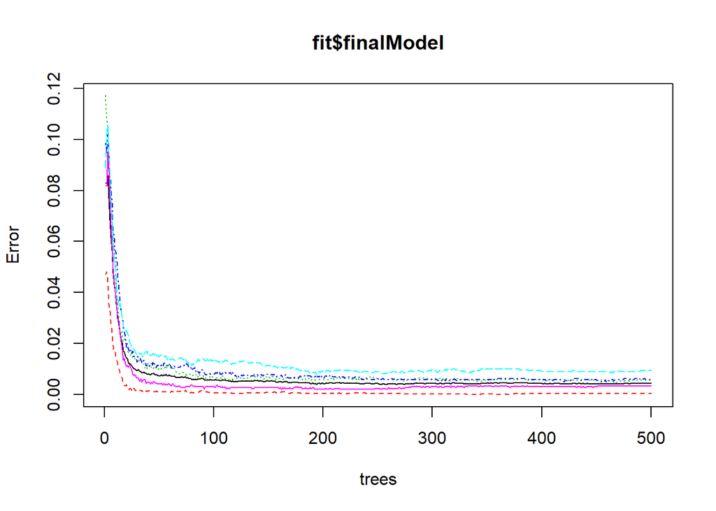

```r
plot(fit$finalModel)
```

```r
pred <-predict(fit,newdata=testing)
confusionMatrix(data=pred,reference=testing$classe)
```

```
## Confusion Matrix and Statistics
##
##           Reference
## Prediction    A    B    C    D    E
##          A 1116    9    0    0    0
##          B    0  750    1    0    0
##          C    0    0  683    6    0
##          D    0    0    0  636    0
##          E    0    0    0    1  721
##
## Overall Statistics
##
##                Accuracy : 0.9957
##                  95% CI : (0.9931, 0.9975)
##     No Information Rate : 0.2845
##     P-Value [Acc > NIR] : < 2.2e-16
##
##                   Kappa : 0.9945
##
##  Mcnemar's Test P-Value : NA
##
## Statistics by Class:
##
##                      Class: A Class: B Class: C Class: D Class: E
## Sensitivity            1.0000   0.9881   0.9985   0.9891   1.0000
## Specificity            0.9968   0.9997   0.9981   1.0000   0.9997
## Pos Pred Value         0.9920   0.9987   0.9913   1.0000   0.9986
## Neg Pred Value         1.0000   0.9972   0.9997   0.9979   1.0000
## Prevalence             0.2845   0.1935   0.1744   0.1639   0.1838
## Detection Rate         0.2845   0.1912   0.1741   0.1621   0.1838
## Detection Prevalence   0.2868   0.1914   0.1756   0.1621   0.1840
## Balanced Accuracy      0.9984   0.9939   0.9983   0.9946   0.9998
```

```r
mt <- fit$bestTune$mtry
print(mt)
```

```
## [1] 7
```

OOB error is less than previously with this optimized model. Regarding the error plot for OOB, we can try to use less trees to save time but keep good accuracy

**Third model (optimized model)**

```r
t1=proc.time() # Record time for measurement

cls = makeCluster(detectCores() - 1)  # initialise parallel computations
registerDoParallel(cls)
fit <- train(x,y, method="rf",trControl = fitControl,tuneGrid=data.frame(mtry=mt),ntree=300)
stopCluster(cls)
registerDoSEQ()

t2=proc.time()
(t2-t1)/60
```

```
##      user    system   elapsed
## 0.4113333 0.0065000 0.9760000
```

```r
OOBErr(fit$finalModel)
```

```
## [1] 0.4458883
```

```r
pred <-predict(fit,newdata=testing)
confusionMatrix(data=pred,reference=testing$classe)
```

```
## Confusion Matrix and Statistics
##
##           Reference
## Prediction    A    B    C    D    E
##          A 1116    7    0    0    0
##          B    0  752    0    0    0
##          C    0    0  684    7    0
##          D    0    0    0  635    0
##          E    0    0    0    1  721
##
## Overall Statistics
##
##                Accuracy : 0.9962
##                  95% CI : (0.9937, 0.9979)
##     No Information Rate : 0.2845
##     P-Value [Acc > NIR] : < 2.2e-16
##
##                   Kappa : 0.9952
##
##  Mcnemar's Test P-Value : NA
##
## Statistics by Class:
##
##                      Class: A Class: B Class: C Class: D Class: E
## Sensitivity            1.0000   0.9908   1.0000   0.9876   1.0000
## Specificity            0.9975   1.0000   0.9978   1.0000   0.9997
## Pos Pred Value         0.9938   1.0000   0.9899   1.0000   0.9986
## Neg Pred Value         1.0000   0.9978   1.0000   0.9976   1.0000
## Prevalence             0.2845   0.1935   0.1744   0.1639   0.1838
## Detection Rate         0.2845   0.1917   0.1744   0.1619   0.1838
## Detection Prevalence   0.2863   0.1917   0.1761   0.1619   0.1840
## Balanced Accuracy      0.9988   0.9954   0.9989   0.9938   0.9998
```

```r
varImp(fit)
```

```
## rf variable importance
##
##   only 20 most important variables shown (out of 52)
##
##                      Overall
## roll_belt             100.00
## yaw_belt               68.16
## pitch_forearm          62.72
## magnet_dumbbell_z      58.84
## pitch_belt             54.20
## magnet_dumbbell_y      53.45
## roll_forearm           46.79
## magnet_dumbbell_x      34.15
## accel_dumbbell_y       30.14
## magnet_belt_y          29.84
## roll_dumbbell          29.74
## magnet_belt_z          29.38
## accel_belt_z           25.44
## accel_dumbbell_z       22.64
## roll_arm               21.68
## accel_forearm_x        20.96
## magnet_forearm_z       19.54
## gyros_belt_z           19.12
## total_accel_dumbbell   17.03
## accel_forearm_z        16.60
```

Predictions on the test set:

```r
pred <-predict(fit,newdata=pml_test)
print(pred)
```

```
##  [1] B A B A A E D B A A B C B A E E A B B B
## Levels: A B C D E
```